# 热门数据挖掘模型应用入门（一）: LASSO回归

侯澄钧

2016年8月31日

- 模型简介
- 线性回归
- Logistic回归
- Elstic Net模型家族简介
- 学习资料

## 模型简介

Kaggle网站 https://www.kaggle.com/ 成立于2010年，是当下最流行的进行数据发掘和预测模型竞赛的在线平台。 与Kaggle合作的公司可以在网站上提出一个问题或者目标，同时提供相关数据，来自世界各地的计算机科学家、统计学家和建模爱好者，将受领任务，通过比较模型的某些性能参数，角逐出优胜者。 通过大量的比赛，一系列优秀的数据挖掘模型脱颖而出，受到广大建模者的认同，被普遍应用在各个领域。 在保险行业中用于拟合广义线性模型的LASSO回归就是其中之一。

LASSO回归的特点是在拟合广义线性模型的同时进行变量筛选(Variable Selection)和复杂度调整(Regularization)。 因此，不论目标因变量(dependent/response varaible)是连续的(continuous)，还是二元或者多元离散的(discrete)， 都可以用LASSO回归建模然后预测。 这里的变量筛选是指不把所有的变量都放入模型中进行拟合，而是有选择的把变量放入模型从而得到更好的性能参数。 复杂度调整是指通过一系列参数控制模型的复杂度，从而避免过度拟合(Overfitting)。 对于线性模型来说，复杂度与模型的变量数有直接关系，变量数越多，模型复杂度就越高。 更多的变量在拟合时往往可以给出一个看似更好的模型，但是同时也面临过度拟合的危险。 此时如果用全新的数据去验证模型(Validation)，通常效果很差。 一般来说，变量数大于数据点数量很多，或者某一个离散变量有太多独特值时，都有可能过度拟合。

LASSO回归复杂度调整的程度由参数$\lambda$来控制，$\lambda$越大对变量较多的线性模型的惩罚力度就越大，从而最终获得一个变量较少的模型。 LASSO回归与Ridge回归同属于一个被称为Elastic Net的广义线性模型家族。 这一家族的模型除了相同作用的参数$\lambda$之外，还有另一个参数$\alpha$来控制应对高相关性(highly correlated)数据时模型的性状。 LASSO回归$\alpha=1$，Ridge回归$\alpha=0$，一般Elastic Net模型$0<\alpha<1$。 这篇文章主要介绍LASSO回归，所以我们集中关注$\alpha=1$的情况，对于另外两种模型的特点和如何选取最优$\alpha$值，我会在第四节做一些简单阐述。

目前最好用的拟合广义线性模型的R package是**glmnet**，由LASSO回归的发明人，斯坦福统计学家Trevor Hastie领衔开发。 它的特点是对一系列不同$\lambda$值进行拟合，每次拟合都用到上一个$\lambda$值拟合的结果，从而大大提高了运算效率。 此外它还包括了并行计算的功能，这样就能调动一台计算机的多个核或者多个计算机的运算网络，进一步缩短运算时间。

## 线性回归

我们从最简单的线性回归(Linear Regression)开始了解如何使用**glmnet**拟合LASSO回归模型，所以此时的连接函数(Link Function)就是恒等，或者说没有连接函数，而误差的函数分布是正态分布。

首先我们装载**glmnet** package，然后读入试验用数据“LinearExample.RData”，[下载链接](https://github.com/cran/glmnet/blob/master/data/QuickStartExample.RData):

```r
library(glmnet)
load("LinearExample.RData")
```

之后在workspace里我们会得到一个$100 \times 20$的矩阵$x$作为输入自变量，$100 \times 1$的矩阵$y$作为目标因变量。 矩阵$x$代表了我们有100个数据点，每个数据点有20个统计量(feature)。现在我们就可以用函数`glmnet()`建模了:

```r
fit = glmnet(x, y, family="gaussian", nlambda=50, alpha=1)
```

好，建模完毕，至此结束本教程 :)

觉得意犹未尽的朋友可以接着看下面的内容。

参数`family`规定了回归模型的类型:

- `family="gaussian"`适用于一维连续因变量(univariate)
- `family="mgaussian"`适用于多维连续因变量(multivariate)
- `family="poisson"`适用于非负次数因变量(count)
- `family="binomial"`适用于二元离散因变量(binary)
- `family="multinomial"`适用于多元离散因变量(category)

参数`nlambda=50`让算法自动挑选50个不同的$\lambda$值，拟合出50个系数不同的模型。 `alpha=1`输入$\alpha$值，1是它的默认值。 值得注意的是，**glmnet**只能接受数值矩阵作为模型输入，如果自变量中有离散变量的话，需要把这一列离散变量转化为几列只含有0和1的向量，这个过程叫做One Hot Encoding。通过下面这个小例子，你可以了解One Hot Encoding的原理以及方法:

```r
df=data.frame(Factor=factor(1:5), Character=c("a","a","b","b","c"),
              Logical=c(T,F,T,T,T), Numeric=c(2.1,2.3,2.5,4.1,1.1))
model.matrix(~., df)
```

```
##   (Intercept) Factor2 Factor3 Factor4 Factor5 Characterb Characterc
## 1           1       0       0       0       0          0          0
## 2           1       1       0       0       0          0          0
## 3           1       0       1       0       0          1          0
## 4           1       0       0       1       0          1          0
## 5           1       0       0       0       1          0          1
##   LogicalTRUE Numeric
## 1           1     2.1
## 2           0     2.3
## 3           1     2.5
## 4           1     4.1
## 5           1     1.1
## attr(,"assign")
## [1] 0 1 1 1 1 2 2 3 4
## attr(,"contrasts")
## attr(,"contrasts")$Factor
## [1] "contr.treatment"
##
## attr(,"contrasts")$Character
## [1] "contr.treatment"
##
## attr(,"contrasts")$Logical
## [1] "contr.treatment"
```

除此之外，如果我们想让模型的变量系数都在同一个数量级上，就需要在拟合前对数据的每一列进行标准化(standardize)，即对每个列元素减去这一列的均值然后除以这一列的标准差。这一过程可以通过在`glmnet()`函数中添加参数`standardize = TRUE`来实现。

回到我们的拟合结果`fit`。作为一个R对象，我们可以把它当作很多函数的输入。比如说，我们可以查看详细的拟合结果:

```r
print(fit)
```

```
##
## Call:  glmnet(x = x, y = y, family = "gaussian", alpha = 1, nlambda = 50)
##
##       Df   %Dev   Lambda
##  [1,]  0 0.0000 1.631000
##  [2,]  2 0.1476 1.351000
##  [3,]  2 0.2859 1.120000
##  [4,]  4 0.3946 0.927900
##  [5,]  5 0.5198 0.768900
##  [6,]  6 0.6303 0.637100
##  [7,]  6 0.7085 0.528000
##  [8,]  7 0.7657 0.437500
##  [9,]  7 0.8081 0.362500
## [10,]  7 0.8373 0.300400
## [11,]  7 0.8572 0.248900
```

[output cut: 25 more lines]

我们也可以通过指定$\lambda$值，抓取出某一个模型的系数:

```r
coef(fit, s=c(fit$lambda[16],0.1))
```

```
## 21 x 2 sparse Matrix of class "dgCMatrix"
##                        1            2
## (Intercept)  0.150672014  0.150910983
## V1           1.322088892  1.320532088
## V2           .            .
## V3           0.677692624  0.674955779
## V4           .            .
## V5          -0.819674385 -0.817314761
## V6           0.523912698  0.521565712
## V7           0.007293509  0.006297101
## V8           0.321450451  0.319344250
## V9           .            .
## V10          .            .
## V11          0.145727982  0.142574921
## V12          .            .
## V13          .            .
## V14         -1.061733786 -1.060031309
## V15          .            .
## V16          .            .
## V17          .            .
## V18          .            .
## V19          .            .
## V20         -1.025371209 -1.021771038
```

需要注意的是，我们把指定的$\lambda$值放在`s=`里，因为在后面Logistic回归的部分我们还用到了`s="lambda.min"`的方法指定$\lambda$的值。 当指定的$\lambda$值不在`fit$lambda`中时，对应的模型系数由Linear Interpolation近似得到。 我们还可以做图观察这50个模型的系数是如何变化的:

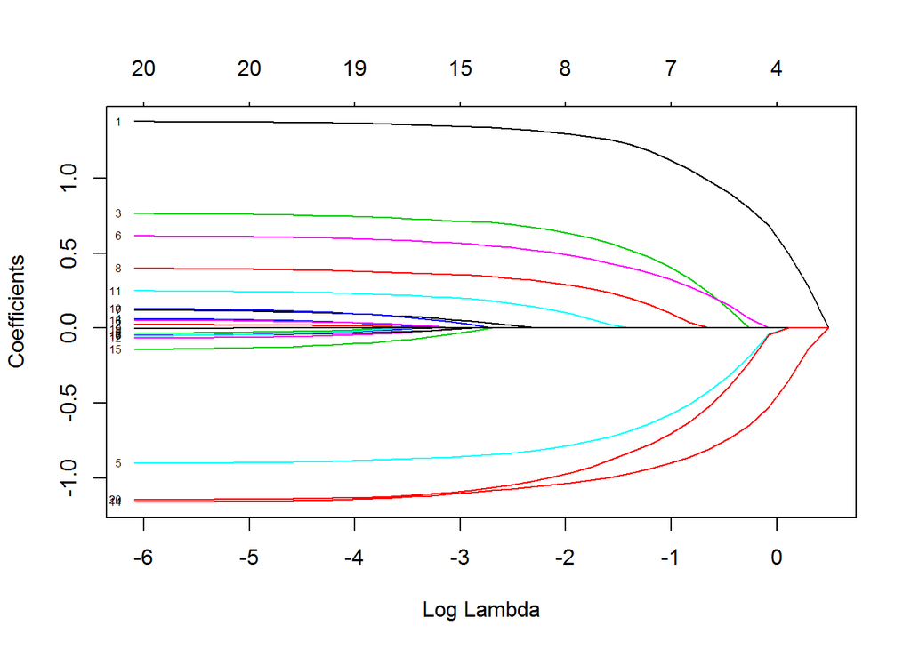

```r
plot(fit, xvar="lambda", label=TRUE)
```

图中的每一条曲线代表了每一个自变量系数的变化轨迹，纵坐标是系数的值，下横坐标是$\log(\lambda)$，上横坐标是此时模型中非零系数的个数。 我们可以看到，黑线代表的自变量1在$\lambda$值很大时就有非零的系数，然后随着$\lambda$值变小不断变大。 我们还可以尝试用`xvar=“norm”`和`xvar=“dev”`切换下横坐标。

接下来当然就是指定$\lambda$值，然后对新数据进行预测了:

```r
nx = matrix(rnorm(5*20),5,20)
predict(fit, newx=nx, s=c(fit$lambda[16],0.1))
```

```
##               1          2
## [1,] -0.9428437 -0.9411604
## [2,] -2.7062121 -2.6982294
## [3,] -0.5348583 -0.5287078
## [4,] -0.3837802 -0.3796019
## [5,] -3.5282290 -3.5257648
```

下面我们再来看几个`glmnet()`函数的其他功能。 使用`upper.limits`和`lower.limits`，我们可以指定模型系数的上限与下限:

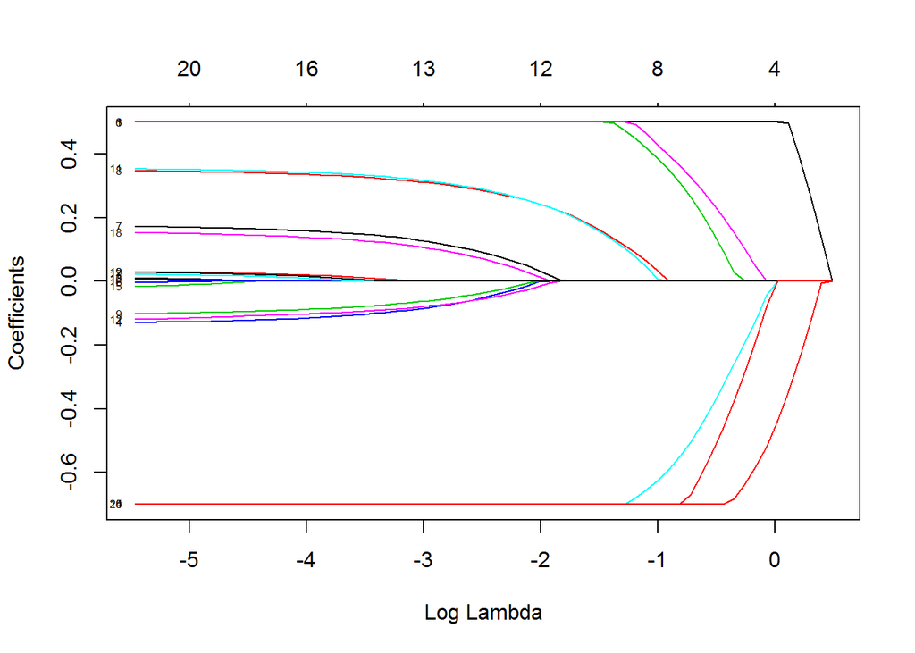

```r
lfit=glmnet(x, y, lower=-.7, upper=.5)
plot(lfit, xvar="lambda", label=TRUE)
```

上限与下限可以是一个值，也可以是一个向量，向量的每一个值作为对应自变量的参数上下限。 有时，在建模之前我们就想凸显某几个自变量的作用，此时我们可以调整惩罚参数。 每个自变量的默认惩罚参数是1，把其中的某几个量设为0将使得相应的自变量不遭受任何惩罚:

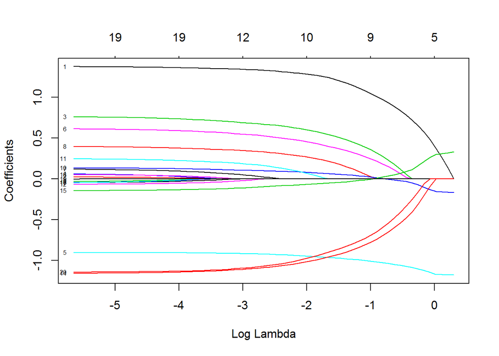

```r
p.fac = rep(1, 20)
p.fac[c(5, 10, 15)] = 0
pfit = glmnet(x, y, penalty.factor=p.fac)
plot(pfit, xvar="lambda", label = TRUE)
```

我们可以看到，自变量5/10/15的系数一直不为0，而其他的参数系数绝对值随着$\lambda$值变小而变大。

## Logistic回归

当面对离散因变量时，特别是面对二元因变量(Yes/No)这样的问题时，Logistic回归被广泛使用。 此时我们用`family="binomial"`来应对这种目标因变量是二项分布(binomial)的情况。

试验用数据“LogisticExample.RData”里储存了$100 \times 30$的矩阵$x$，和元素是0/1长度是100的向量$y$，[下载链接](https://github.com/cran/glmnet/blob/master/data/BinomialExample.RData):

```r
load("LogisticExample.RData")
```

我们可以用上一节介绍的`glmnet()`函数来拟合模型，然后选取最优的$\lambda$值。但是在这种方法下，所有数据都被用来做了一次拟合，这很有可能会造成过拟合的。在这种情况下，当我们把得到的模型用来预测全新收集到的数据时，结果很可能会不尽如人意。 所以只要条件允许，我们都会用交叉验证(Cross Validation)拟合进而选取模型，同时对模型的性能有一个更准确的估计。

```r
cvfit = cv.glmnet(x, y, family = "binomial", type.measure = "class")
```

这里的`type.measure`是用来指定交叉验证选取模型时希望最小化的目标参量，对于Logistic回归有以下几种选择:

- `type.measure=deviance` 使用deviance，即-2倍的Log-likelihood
- `type.measure=mse` 使用拟合因变量与实际应变量的mean squred error
- `type.measure=mae` 使用mean absolute error
- `type.measure=class` 使用模型分类的错误率(missclassification error)
- `type.measure=auc` 使用area under the ROC curve，是现在最流行的综合考量模型性能的一种参数

除此之外，在`cv.glmnet()`里我们还可以用`nfolds`指定fold数，或者用`foldid`指定每个fold的内容。 因为每个fold间的计算是独立的，我们还可以考虑运用并行计算来提高运算效率，使用`parallel=TRUE`可以开启这个功能。 但是我们需要先装载package **doParallel**。 下面我们给出在Windows操作系统和Linux操作系统下开启并行计算的示例:

```r
library(doParallel)
# Windows System
cl <- makeCluster(6)
registerDoParallel(cl)
cvfit = cv.glmnet(x, y, family = "binomial", type.measure = "class", parallel=TRUE)
stopCluster(cl)
# Linux System
registerDoParallel(cores=8)
cvfit = cv.glmnet(x, y, family = "binomial", type.measure = "class", parallel=TRUE)
stopImplicitCluster()
```

同样的，我们可以绘制`cvfit`对象:

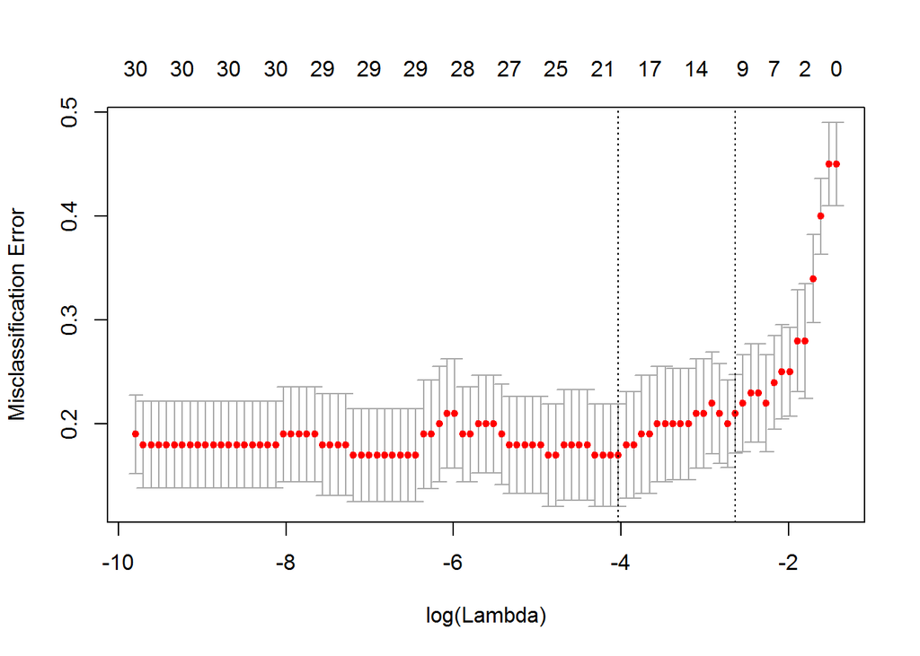

```r
plot(cvfit)
```

因为交叉验证，对于每一个$\lambda$值，在红点所示目标参量的均值左右，我们可以得到一个目标参量的置信区间。 两条虚线分别指示了两个特殊的$\lambda$值:

```r
c(cvfit$lambda.min, cvfit$lambda.1se)
```

```
## [1] 0.01777293 0.07174962
```

`lambda.min`是指在所有的$\lambda$值中，得到最小目标参量均值的那一个。 而`lambda.1se`是指在`lambda.min`一个方差范围内得到最简单模型的那一个$\lambda$值。 因为$\lambda$值到达一定大小之后，继续增加模型自变量个数即缩小$\lambda$值，并不能很显著的提高模型性能，`lambda.1se`给出的就是一个具备优良性能但是自变量个数最少的模型。 同样的，我们可以指定$\lambda$值然后进行预测:

```r
predict(cvfit, newx=x[1:5,], type="response", s="lambda.1se")
```

```
##              1
## [1,] 0.3396639
## [2,] 0.7838029
## [3,] 0.6028035
## [4,] 0.2552859
## [5,] 0.6390665
```

这里的`type`有以下几种选择:

- `type=link` 给出线性预测值，即进行Logit变换之前的值
- `type=response` 给出概率预测值，即进行Logit变换之后的值
- `type=class` 给出0/1预测值
- `type=coefficients` 罗列出给定$\lambda$值时的模型系数
- `type=coefficients` 罗列出给定$\lambda$值时，不为零模型系数的下标

另外，当已有了一个模型之后,我们又得到了几个新的自变量，如果想知道这些新变量能否在第一个模型的基础上提高模型性能，可以把第一个模型的预测因变量作为一个向量放到函数选项`offset`中，再用`glmnet`或者`cv.glmnet`进行拟合。

## Elstic Net模型家族简介

在这一节我们会了解一些关于Elastic Net模型家族的理论。首先我们先来看看一般线性Elastic Net模型的目标函数:

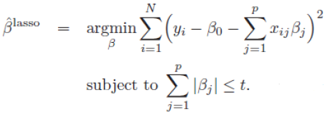

目标函数的第一行与传统线性回归模型完全相同，即我们希望得到相应的自变量系数$\beta$，以此最小化实际因变量$y$与预测应变量$\beta x$之间的误差平方和。 而线性Elastic Net与线性回归的不同之处就在于有无第二行的这个约束，线性Elastic Net希望得到的自变量系数是在由$t$控制的一个范围内。 这一约束也是Elastic Net模型能进行复杂度调整，LASSO回归能进行变量筛选和复杂度调整的原因。 我们可以通过下面的这张图来解释这个道理:

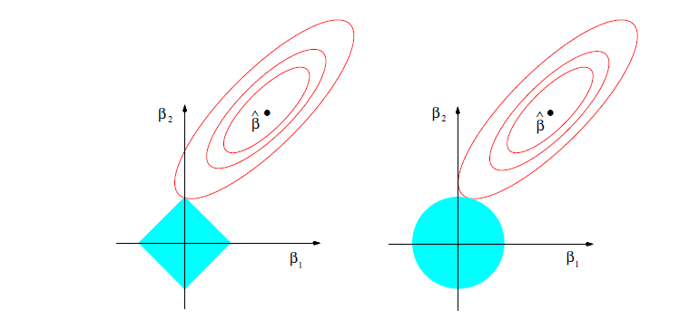

先看左图，假设一个二维模型对应的系数是$\beta_1$和$\beta_2$，然后$\hat{\beta}$是最小化误差平方和的点，即用传统线性回归得到的自变量系数。 但我们想让这个系数点必须落在蓝色的正方形内，所以就有了一系列围绕$\hat{\beta}$的同心椭圆,其中最先与蓝色正方形接触的点，就是符合约束同时最小化误差平方和的点。 这个点就是同一个问题LASSO回归得到的自变量系数。 因为约束是一个正方形，所以除非相切，正方形与同心椭圆的接触点往往在正方形顶点上。而顶点又落在坐标轴上，这就意味着符合约束的自变量系数有一个值是0。 所以这里传统线性回归得到的是$\beta_1$和$\beta_2$都起作用的模型，而LASSO回归得到的是只有$\beta_2$有作用的模型，这就是LASSO回归能筛选变量的原因。

而正方形的大小就决定了复杂度调整的程度。假设这个正方形极小，近似于一个点，那么LASSO回归得到的就是一个只有常量(intercept)而其他自变量系数都为0的模型，这是模型简化的极端情况。 由此我们可以明白，控制复杂度调整程度的$\lambda$值与约束大小$t$是呈反比的，即$\lambda$值越大对参数较多的线性模型的惩罚力度就越大，越容易得到一个简单的模型。

另外，我们之前提到的参数$\alpha$就决定了这个约束的形状。刚才提到LASSO回归($\alpha=1$)的约束是一个正方形，所以更容易让约束后的系数点落在顶点上，从而起到变量筛选或者说降维的目的。 而Ridge回归($\alpha=0$)的约束是一个圆，与同心椭圆的相切点会在圆上的任何位置，所以Ridge回归并没有变量筛选的功能。 相应的，当几个自变量高度相关时，LASSO回归会倾向于选出其中的任意一个加入到筛选后的模型中，而Ridge回归则会把这一组自变量都挑选出来。 至于一般的Elastic Net模型($0<\alpha<1$)，其约束的形状介于正方形与圆形之间，所以其特点就是在任意选出一个自变量或者一组自变量之间权衡。

下面我们就通过Logistic回归一节的例子，来看看这几种模型会得到怎样不同的结果:

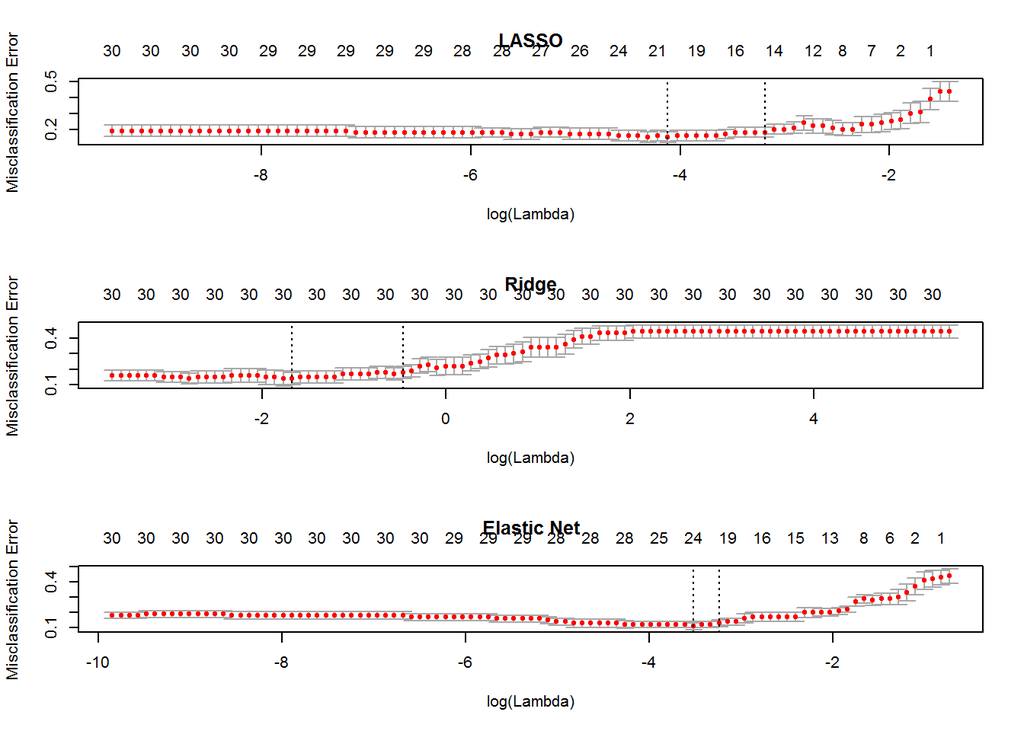

```r
# CV for 11 alpha value
for (i in 0:10) {
  assign(paste("cvfit", i, sep=""),
         cv.glmnet(x, y, family="binomial", type.measure="class", alpha=i/10))
}
# Plot Solution Paths
par(mfrow=c(3,1))
plot(cvfit10, main="LASSO")
plot(cvfit0, main="Ridge")
plot(cvfit5, main="Elastic Net")
```

通过比较可以看出，Ridge回归得到的模型一直都有30个自变量，而$\alpha=0.5$时的Elastic Net与LASSO回归有相似的性能。

## 学习资料

本文的图片来自Trevor Hastie教授的著作“The Elements of Statistical Learning”，我觉得这本书在parametric model这一方向的阐述尤其精彩，对于其他数据挖掘方向也有十分全面的介绍。

以后我也会接着介绍一些其他的常用模型。最后感谢大家的阅读。